# Spatial Analysis

Spatial field variation is common in breeding trials. Mandala can fit simple row-column mixed models and then provide spatial diagnostic plots from the fitted model. The examples use a small augmented single-location trial.

## Data Preparation

```r
library(mandala)

aug <- read.csv(
  system.file("extdata", "augmented_single_n200.csv", package = "mandala"),
  stringsAsFactors = FALSE,
  check.names = FALSE
)

for (v in c("geno", "row", "col")) {
  aug[[v]] <- factor(aug[[v]])
}

aug$yld <- as.numeric(aug$yld)
```

This dataset has many unreplicated genotypes and a smaller set of replicated check genotypes. Row and column describe the field position of each plot.

```r
data.frame(
  plots = nrow(aug),
  genotypes = length(unique(aug$geno)),
  replicated_genotypes = sum(table(aug$geno) > 1),
  unreplicated_genotypes = sum(table(aug$geno) == 1),
  rows = length(unique(aug$row)),
  columns = length(unique(aug$col))
)
```

```
#>   plots genotypes replicated_genotypes unreplicated_genotypes rows columns
#> 1   200       160                   20                    140   14      15
```

## Model 1: Genotype Baseline

The first model estimates genotype effects without using field-position information. This gives a simple baseline for judging spatial adjustment.

```r
fit_base <- mandala(
  yld ~ 1,
  ~ geno,
  data = aug,
  verbose = FALSE
)

summary(fit_base)
```

```
#> Model statement:
#> mandala(fixed = yld ~ 1, random = ~geno, data = aug, verbose = FALSE)
#>
#> Variance Components:
#>  component  estimate  std.error  z.ratio bound %ch
#>       geno 0.6686315 0.14727894 4.539899     P  NA
#>   R.sigma2 0.4571173 0.09963492 4.587923     P  NA
#>
#> Fixed Effects (BLUEs) [first 5]:
#>       effect estimate std.error  z.ratio
#>  (Intercept) 7.149171 0.0819997 87.18534
#>
#> Converged: TRUE  |  Iterations: 5
#>
#> Model Notes:
#> - Selected prediction SEs are available through mandala_predict().
#> - Selected fixed-effect tests are available with mandala_fixed_tests(type = 'selected').
#>
#> Random Effects (BLUPs) [first 5]:
#>  random level   estimate std.error     z.ratio
#>    geno    G1 -0.0259458 0.3585428 -0.07236459
#>    geno   G10 -0.6446108 0.3585428 -1.79786301
#>    geno  G100  0.4141553 0.5233297  0.79138499
#>    geno  G101 -0.1874388 0.5233297 -0.35816584
#>    geno  G102  0.6048431 0.5233297  1.15575913
#>
#> logLik: -286.519   AIC: 577.037   BIC: 583.624   logLik_Trunc: -103.650
```

## Model 2: Row-Column Spatial Adjustment

The second model adds row and column effects. This is a simple row-column spatial adjustment: it does not assume a full AR1 residual model, but it is a useful first step for field trends that align with rows or columns.

```r
fit_spatial <- mandala(
  yld ~ 1,
  ~ geno + row + col,
  data = aug,
  verbose = FALSE
)

summary(fit_spatial)
```

```
#> Model statement:
#> mandala(fixed = yld ~ 1, random = ~geno + row + col, data = aug,
#>     verbose = FALSE)
#>
#> Variance Components:
#>  component   estimate  std.error  z.ratio bound %ch
#>       geno 0.42983930 0.06126367 7.016218     P  NA
#>        row 0.29599940 0.12308129 2.404910     P  NA
#>        col 0.30309231 0.12172672 2.489941     P  NA
#>   R.sigma2 0.06052303 0.01945609 3.110749     P  NA
#>
#> Fixed Effects (BLUEs) [first 5]:
#>       effect estimate std.error  z.ratio
#>  (Intercept) 7.186965 0.2108871 34.07968
#>
#> Converged: TRUE  |  Iterations: 11
#>
#> Model Notes:
#> - Selected prediction SEs are available through mandala_predict().
#> - Selected fixed-effect tests are available with mandala_fixed_tests(type = 'selected').
#>
#> Random Effects (BLUPs) [first 5]:
#>  random level    estimate std.error    z.ratio
#>    geno    G1 -0.34350610 0.1730044 -1.9855338
#>    geno   G10 -0.69072325 0.1787749 -3.8636481
#>    geno  G100  0.42780962 0.2863221  1.4941552
#>    geno  G101  0.06766663 0.2869923  0.2357785
#>    geno  G102  0.37495894 0.2763080  1.3570326
#>
#> logLik: -222.107   AIC: 452.214   BIC: 465.387   logLik_Trunc: -39.238
```

## Alternative Spatial Models

Mandala can also fit residual AR1 structures through `R_formula`. A one-margin AR1 model is written by crossing an identity margin with an AR1 margin. A separable two-dimensional residual model is written as `ar1(row):ar1(col)`.

```r
fit_ar1_col <- mandala(
  yld ~ 1,
  ~ geno,
  data = aug,
  R_formula = ~ id(row):ar1(col),
  verbose = FALSE
)

fit_ar1_row <- mandala(
  yld ~ 1,
  ~ geno,
  data = aug,
  R_formula = ~ ar1(row):id(col),
  verbose = FALSE
)

fit_ar1_2d <- mandala(
  yld ~ 1,
  ~ geno,
  data = aug,
  R_formula = ~ ar1(row):ar1(col),
  verbose = FALSE
)

rbind(
  ar1_col = fit_ar1_col$varcomp,
  ar1_row = fit_ar1_row$varcomp,
  ar1_2d = fit_ar1_2d$varcomp
)
```

```
#>           component  estimate  std.error   z.ratio bound %ch
#> ar1_col.1      geno 0.3678125 0.07474901  4.920634     P  NA
#> ar1_col.2  R.sigma2 0.7903385 0.07467178 10.584166     P  NA
#> ar1_col.3 R.rho.col 0.8550000 0.34497086  2.478470     P  NA
#> ar1_row.1      geno 0.4952079 0.08177405  6.055807     P  NA
#> ar1_row.2  R.sigma2 0.5176285 0.05140675 10.069272     P  NA
#> ar1_row.3 R.rho.row 0.8575177 0.25926688  3.307471     P  NA
#> ar1_2d.1       geno 0.4007287 0.06639072  6.035915     P  NA
#> ar1_2d.2   R.sigma2 0.3149987 0.05321163  5.919735     P  NA
#> ar1_2d.3  R.rho.row 0.4457830 0.06824734  6.531873     P  NA
#> ar1_2d.4  R.rho.col 0.7079273 0.13492079  5.246984     P  NA
```

A two-dimensional spline can be fitted as a random spatial smooth. The compact call `pspline2D(row, col)` creates internal numeric coordinates and adds the spatial plane used by Mandala’s spline model.

```r
fit_spline <- mandala(
  yld ~ 1,
  ~ geno + pspline2D(row, col),
  data = aug,
  verbose = FALSE
)

fit_spline$varcomp
```

```
#>               component    estimate  std.error    z.ratio bound %ch
#> 1                  geno 0.445503646 0.06530119 6.82228944     P  NA
#> 2            f(row.num) 0.357005638 0.41565919 0.85889027     P  NA
#> 3            f(col.num) 0.224737496 0.27146797 0.82786007     P  NA
#> 4    f(row.num):col.num 0.006806629 0.17435814 0.03903820     P  NA
#> 5    row.num:f(col.num) 0.006806629 0.07019476 0.09696776     P  NA
#> 6 f(row.num):f(col.num) 0.010268015 0.02003222 0.51257493     P  NA
#> 7                   row 0.006806629 0.01855800 0.36677592     P  NA
#> 8                   col 0.064312123 0.04266959 1.50721224     P  NA
#> 9              R.sigma2 0.056571369 0.01992362 2.83941213     P  NA
```

## Model Evaluation

For models fitted to the same response and data, `logLik`, `AIC`, and `BIC` provide a quick model comparison. Lower `AIC` or `BIC` is preferred, while a higher `logLik` indicates better likelihood fit.

```r
fit_list <- list(
  baseline = fit_base,
  row_col = fit_spatial,
  ar1_col = fit_ar1_col,
  ar1_row = fit_ar1_row,
  ar1_row_col = fit_ar1_2d,
  pspline2D = fit_spline
)

model_compare <- data.frame(
  model = c("baseline", "row_col", "ar1_col", "ar1_row", "ar1_row_col", "pspline2D"),
  logLik = c(
    fit_base$logLik,
    fit_spatial$logLik,
    fit_ar1_col$logLik,
    fit_ar1_row$logLik,
    fit_ar1_2d$logLik,
    fit_spline$logLik
  ),
  AIC = c(
    fit_base$AIC,
    fit_spatial$AIC,
    fit_ar1_col$AIC,
    fit_ar1_row$AIC,
    fit_ar1_2d$AIC,
    fit_spline$AIC
  ),
  BIC = c(
    fit_base$BIC,
    fit_spatial$BIC,
    fit_ar1_col$BIC,
    fit_ar1_row$BIC,
    fit_ar1_2d$BIC,
    fit_spline$BIC
  )
)

model_compare
```

```
#>         model    logLik      AIC      BIC
#> 1    baseline -286.5187 577.0375 583.6241
#> 2     row_col -222.1069 452.2138 465.3870
#> 3     ar1_col -240.7168 487.4337 497.3136
#> 4     ar1_row -244.3509 494.7018 504.5818
#> 5 ar1_row_col -230.0119 468.0237 481.1970
#> 6   pspline2D -212.7031 443.4061 472.9092
```

```r
best_model <- model_compare$model[which.min(model_compare$AIC)]
best_fit <- fit_list[[best_model]]
best_model
```

```
#> [1] "pspline2D"
```

In this augmented example, the row-column and spline models should improve the fit over the baseline model because the dataset contains a clear field trend. The best model is still a statistical choice: compare fit, parsimony, residual diagnostics, and whether the spatial terms make sense for the field layout.

## Fixed-Effect Test

This example has only an intercept fixed effect, so the fixed-effect test is mostly a workflow demonstration. In trials with treatments, environments, or covariates, the same function tests those fixed terms.

```r
mandala_fixed_tests(best_fit, type = "selected", denDF = "residual")
```

```
#>
#> Fixed-effect term tests
#> -----------------------
#> Method: selected
#> Denominator df: residual
#>
#>                 Df denDF       F.inc        Wald           Pr status
#> (Intercept)      1   196 820.8275192 820.8275192 5.396274e-72     ok
#> row.num          1   196  30.8677667  30.8677667 8.928691e-08     ok
#> col.num          1   196  12.7333661  12.7333661 4.516097e-04     ok
#> row.num:col.num  1   196   0.2266391   0.2266391 6.345574e-01     ok
#>
#> Note:
#> - Residual df were used for all fixed-effect terms.
```

## Standard Diagnostics

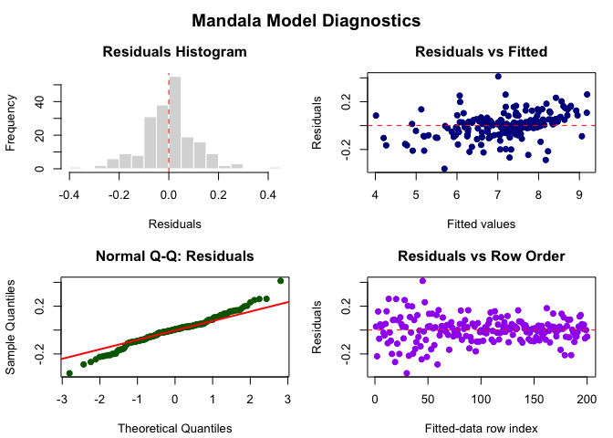

```r
mandala_diagnostic_plots(best_fit, response = "yld")
```

## Spatial Diagnostics

`mandala_spatial_diagnostics()` shows observed values, fitted values, residuals, and a smoothed spatial surface. This is often the fastest way to see whether spatial pattern remains after fitting the model.

```r
mandala_spatial_diagnostics(
  best_fit,
  data = aug,
  response = "yld",
  row = "row",
  col = "col"
)
```

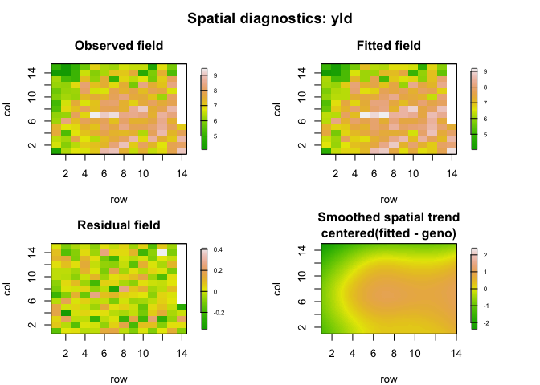

## Empirical Variogram

The empirical variogram summarizes how residual similarity changes with field distance. Strong structure in the variogram can indicate remaining spatial pattern.

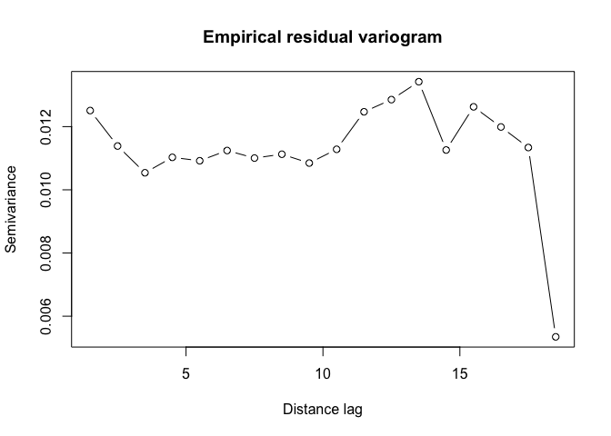

```r
vg_2d <- mandala_variogram(
  best_fit,
  data = aug,
  response = "yld",
  row = "row",
  col = "col",
  plot_type = "2d"
)
```

The same empirical variogram can also be displayed as a 3-D surface.

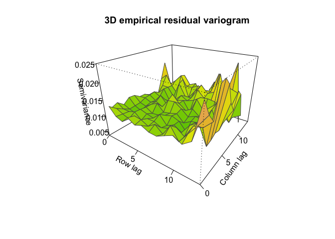

```r
vg_3d <- mandala_variogram(
  best_fit,
  data = aug,
  response = "yld",
  row = "row",
  col = "col",
  plot_type = "3d"
)
```

## Genotype Prediction

Finally, predict adjusted genotype values from the spatial model.

```r
pred_aug <- mandala_predict(best_fit, "geno", present = TRUE, verbose = FALSE)
head(pred_aug)
```

```
#>   geno predicted_value std_error
#> 1   G1        6.884606 0.1725286
#> 2  G10        6.492034 0.1826274
#> 3 G100        7.522207 0.2754595
#> 4 G101        7.260529 0.2822562
#> 5 G102        7.467809 0.2672455
#> 6 G103        7.029064 0.2638560
```

## Quick SpATS Comparison

If SpATS is installed, a comparable genotype-random spatial spline can be fitted and compared with Mandala’s spline model through fitted values.

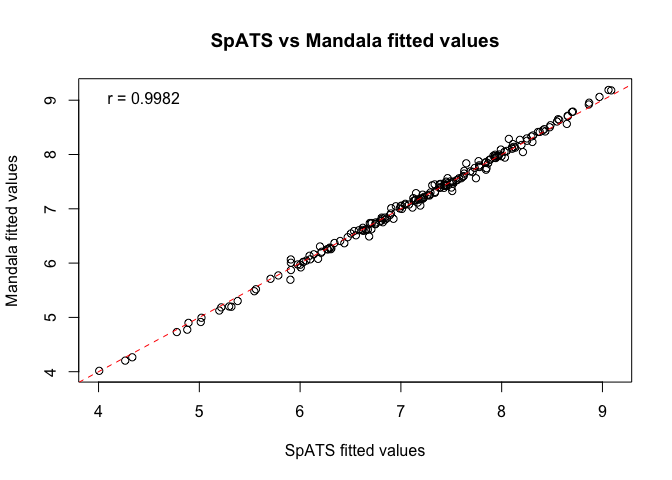

```
#>   fitted_correlation
#> 1          0.9981549
```

```r
if (requireNamespace("SpATS", quietly = TRUE)) {
  aug$row_num <- as.numeric(as.character(aug$row))
  aug$col_num <- as.numeric(as.character(aug$col))

  fit_spats <- SpATS::SpATS(
    response = "yld",
    genotype = "geno",
    genotype.as.random = TRUE,
    spatial = ~ SpATS::SAP(row_num, col_num, nseg = c(8, 8), degree = 3, pord = 2),
    data = aug,
    control = SpATS::controlSpATS(tolerance = 1e-03, monitoring = 0)
  )

  fitted_spats <- as.numeric(fit_spats$fitted)
  fitted_mandala <- as.numeric(fit_spline$fitted)
  comp_df <- data.frame(
    yld = aug$yld,
    fitted_spats = fitted_spats,
    fitted_mandala = fitted_mandala
  )
  r_fit <- cor(comp_df$fitted_spats, comp_df$fitted_mandala)

  plot(
    comp_df$fitted_spats, comp_df$fitted_mandala,
    xlab = "SpATS fitted values",
    ylab = "Mandala fitted values",
    main = "SpATS vs Mandala fitted values"
  )
  abline(0, 1, col = "red", lty = 2)
  legend(
    "topleft",
    legend = sprintf("r = %.4f", r_fit),
    bty = "n"
  )

  data.frame(fitted_correlation = r_fit)
} else {
  data.frame(note = "Install SpATS to run this comparison.")
}
```

## Selected Literature

Spatial adjustment is a central component of modern field-trial analysis because fertility gradients, management zones, and local field trends can inflate residual variation or bias genotype comparisons. Row-column random effects, separable AR1 residuals, empirical variograms, and two-dimensional spline smooths are common tools for diagnosing and modeling these trends.

- Gilmour, A. R., Cullis, B. R. and Verbyla, A. P. (1997). Accounting for natural and extraneous variation in the analysis of field experiments. *Journal of Agricultural, Biological, and Environmental Statistics*, 2, 269-293.
- Smith, A., Cullis, B. and Thompson, R. (2001). Analyzing variety by environment data using multiplicative mixed models and adjustments for spatial field trend. *Biometrics*, 57, 1138-1147.
- Cullis, B. R., Smith, A. B. and Coombes, N. E. (2006). On the design of early generation variety trials with correlated data. *Journal of Agricultural, Biological, and Environmental Statistics*, 11, 381-393.
- Eilers, P. H. C. and Marx, B. D. (1996). Flexible smoothing with B-splines and penalties. *Statistical Science*, 11, 89-121.
- Rodríguez-Álvarez, M. X., Boer, M. P., van Eeuwijk, F. A. and Eilers, P. H. C. (2018). Correcting for spatial heterogeneity in plant breeding experiments with P-splines. *Spatial Statistics*, 23, 52-71.